# Dain Hall

### Question 4

Add the predicted values of the logistic regression model to the “bbb” data frame. For the first few observations in the data, visually compare the “buyer” variable to the predicted values. Next, for the full dataset, compare the average of the predicted values with the average of the “buyer” variable. What do you notice? Why is that?

```r
bbbPred <- bbb %>%
   mutate(pred_buyer=predict(lrm, type = "response"))

bbbPred %>% select(buyer, pred_buyer) %>% arrange(desc(pred_buyer))
```

| buyer | pred_buyer |
| --- | --- |
| 1 | 0.984 |
| 1 | 0.976 |
| 1 | 0.973 |
| 1 | 0.972 |
| 1 | 0.971 |
| 1 | 0.957 |
| 1 | 0.954 |
| 1 | 0.954 |
| 1 | 0.951 |
| 1 | 0.948 |

[output cut: 990 more lines]

```r
"
For the entire dataset, the averages of buyer and predicted buyer using the lrm are the same.
It makes sense that this is the case because we used the dataset to generate the lrm model.
"
```

```
[1] "\nFor the entire dataset, the averages of buyer and predicted buyer using the lrm are the same.\nIt makes sense that this is the case because we used the dataset to generate the lrm model.\n"
```

```r
bbbPred %>% summarise(avg_buyer=mean(buyer), avg_pred_buyer=mean(pred_buyer))
```

| avg_buyer | avg_pred_buyer |
| --- | --- |
| 0.0904 | 0.0904 |

## Part 2 - Decile Analysis of Logistic Regression Results

### Question 1

Assign each customer to a decile based on his or her predicted probability of purchase. Assign those with the highest predicted probability of purchase to decile 1 and those with the lowest predicted probability of purchase to decile 10.

```r
decileBBB <- bbbPred %>%
   mutate(pred_buyer_decile = ntile(-pred_buyer, 10)) %>%
   group_by(pred_buyer_decile) %>%
   summarise(num_cust=n(), num_buyers=sum(buyer), resp_rate=sum(buyer)/n(), pred_resp_rate=mean(pred_buyer))

decileBBB
```

| pred_buyer_decile | num_cust | num_buyers | resp_rate | pred_resp_rate |
| --- | --- | --- | --- | --- |
| 1 | 5000 | 1935 | 0.3870 | 0.38561 |
| 2 | 5000 | 836 | 0.1672 | 0.16384 |
| 3 | 5000 | 511 | 0.1022 | 0.10485 |
| 4 | 5000 | 368 | 0.0736 | 0.07414 |
| 5 | 5000 | 284 | 0.0568 | 0.05564 |
| 6 | 5000 | 196 | 0.0392 | 0.04228 |
| 7 | 5000 | 139 | 0.0278 | 0.03210 |
| 8 | 5000 | 121 | 0.0242 | 0.02371 |
| 9 | 5000 | 90 | 0.0180 | 0.01571 |
| 10 | 5000 | 42 | 0.0084 | 0.00651 |

### Question 2

Create a bar chart plotting response rate by decile (as just defined above). Hint: The “response rate” is not the same as the “predicted probability of purchase” that the model generated. Instead, it is the actual percentage of customers in a given group (for example a decile) that have bought “The Art History of Florence.”

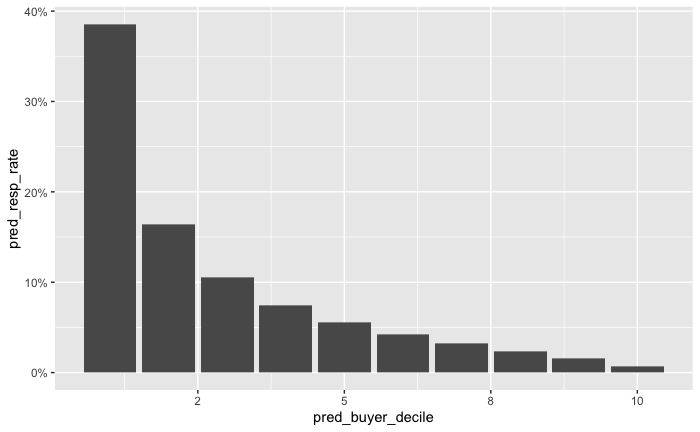

```r
 ggplot(decileBBB, aes(x=pred_buyer_decile, y=pred_resp_rate)) +
   geom_col() +
   scale_x_continuous(labels=scales::number_format(accuracy = 1)) +
   scale_y_continuous(labels=scales::percent_format(accuracy = 1))
```

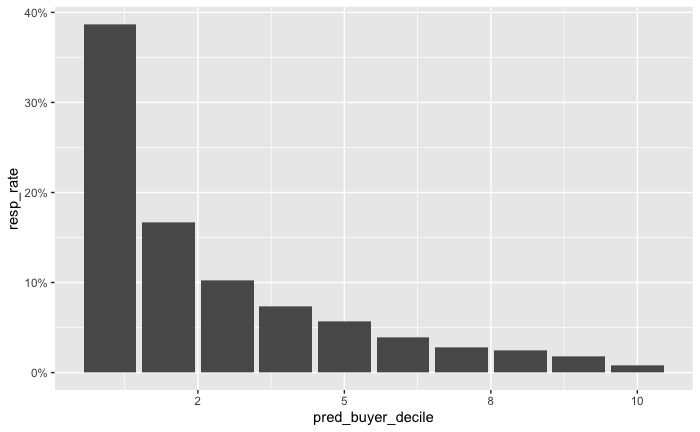

```r
 ggplot(decileBBB, aes(x=pred_buyer_decile, y=resp_rate)) +
   geom_col() +
   scale_x_continuous(labels=scales::number_format(accuracy = 1)) +
   scale_y_continuous(labels=scales::percent_format(accuracy = 1))
```

### Question 3

Generate a report showing number of customers, the number of buyers of “The Art History of Florence’ and the response rate to the offer by decile for the random sample (i.e. the 50,000) customers in the dataset.

```r
decileBBB %>% select(decile=pred_buyer_decile, num_cust, num_buyers, resp_rate)
```

| decile | num_cust | num_buyers | resp_rate |
| --- | --- | --- | --- |
| 1 | 5000 | 1935 | 0.3870 |
| 2 | 5000 | 836 | 0.1672 |
| 3 | 5000 | 511 | 0.1022 |
| 4 | 5000 | 368 | 0.0736 |
| 5 | 5000 | 284 | 0.0568 |
| 6 | 5000 | 196 | 0.0392 |
| 7 | 5000 | 139 | 0.0278 |
| 8 | 5000 | 121 | 0.0242 |
| 9 | 5000 | 90 | 0.0180 |
| 10 | 5000 | 42 | 0.0084 |

```r
NA
```

## Part 3 - Lifts & Gains

### Question 1

Use the information from the report in II.3 above to create a table showing the lift and cumulative lift for each decile. You may want to use Excel for these calculations.

```r
# clipr::write_clip(decileBBB)
total_customers <- sum(decileBBB$num_cust)
total_buyers <- sum(decileBBB$num_buyers)
blended_resp_rate <- total_buyers / total_customers
lift_and_gains <- decileBBB %>%
   mutate(cum_cust=cumsum(num_cust), cum_buyers=cumsum(num_buyers), cum_resp_rate=cumsum(resp_rate), lift=resp_rate / blended_resp_rate, cum_lift=(cum_buyers / cum_cust) / blended_resp_rate, cum_gains=cum_buyers / total_buyers, gains=num_buyers / total_buyers, perc_cum_cust=cum_cust/total_customers) %>%
   select(pred_buyer_decile, num_cust, cum_cust, num_buyers, cum_buyers, gains, cum_gains, lift, cum_lift, perc_cum_cust)

lift_and_gains %>% select(everything(), -perc_cum_cust, -gains, -cum_gains)
```

| pred_buyer_decile | num_cust | cum_cust | num_buyers | cum_buyers | lift | cum_lift |
| --- | --- | --- | --- | --- | --- | --- |
| 1 | 5000 | 5000 | 1935 | 1935 | 4.2791 | 4.28 |
| 2 | 5000 | 10000 | 836 | 2771 | 1.8487 | 3.06 |
| 3 | 5000 | 15000 | 511 | 3282 | 1.1300 | 2.42 |
| 4 | 5000 | 20000 | 368 | 3650 | 0.8138 | 2.02 |
| 5 | 5000 | 25000 | 284 | 3934 | 0.6280 | 1.74 |
| 6 | 5000 | 30000 | 196 | 4130 | 0.4334 | 1.52 |
| 7 | 5000 | 35000 | 139 | 4269 | 0.3074 | 1.35 |
| 8 | 5000 | 40000 | 121 | 4390 | 0.2676 | 1.21 |
| 9 | 5000 | 45000 | 90 | 4480 | 0.1990 | 1.10 |
| 10 | 5000 | 50000 | 42 | 4522 | 0.0929 | 1.00 |

### Question 2

In Excel, create a chart showing the cumulative lift by decile.

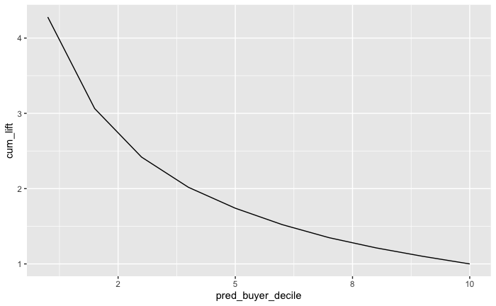

```r
ggplot(lift_and_gains, aes(x=pred_buyer_decile, y=cum_lift)) + geom_line() +
   scale_x_continuous(labels=scales::number_format(accuracy = 1))
```

### Question 3

Use the information from the report in II.3 above to create a table showing the gains and cumulative gains for each decile. You may want to use Excel for these calculations.

```r
lift_and_gains %>% select(everything(), -lift, -cum_lift, -perc_cum_cust)
```

| pred_buyer_decile | num_cust | cum_cust | num_buyers | cum_buyers | gains | cum_gains |
| --- | --- | --- | --- | --- | --- | --- |
| 1 | 5000 | 5000 | 1935 | 1935 | 0.42791 | 0.428 |
| 2 | 5000 | 10000 | 836 | 2771 | 0.18487 | 0.613 |
| 3 | 5000 | 15000 | 511 | 3282 | 0.11300 | 0.726 |
| 4 | 5000 | 20000 | 368 | 3650 | 0.08138 | 0.807 |
| 5 | 5000 | 25000 | 284 | 3934 | 0.06280 | 0.870 |
| 6 | 5000 | 30000 | 196 | 4130 | 0.04334 | 0.913 |
| 7 | 5000 | 35000 | 139 | 4269 | 0.03074 | 0.944 |
| 8 | 5000 | 40000 | 121 | 4390 | 0.02676 | 0.971 |
| 9 | 5000 | 45000 | 90 | 4480 | 0.01990 | 0.991 |
| 10 | 5000 | 50000 | 42 | 4522 | 0.00929 | 1.000 |

### Question 4

In Excel, create a chart showing the cumulative gains by decile along with a reference line corresponding to ‘no model’.

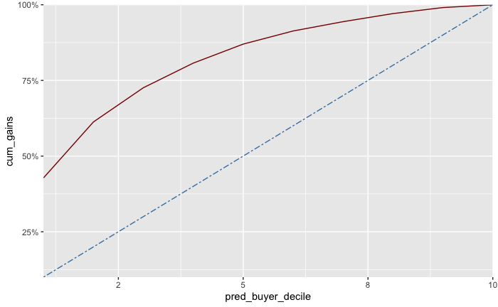

```r
ggplot(lift_and_gains, aes(x=pred_buyer_decile)) +
   geom_line(aes(y = cum_gains), color = "darkred") +
   geom_line(aes(y = perc_cum_cust), color="steelblue", linetype="twodash")  +
   scale_x_continuous(labels=scales::number_format(accuracy = 1), expand = c(0, 0)) +
   scale_y_continuous(labels=scales::percent_format(accuracy = 1), expand = c(0, 0)) +
   theme(
      legend.position = c(0.95, 0.95),
      legend.justification = c("right", "top")
   )
```

```r
"
GRADER PLEASE NOTE: there may be a bug in ggplot where with 'expand' - I could not get the x/y axis to correctly start at 0, so the gains are shifted
"
```

```
[1] "\nGRADER PLEASE NOTE: there may be a bug in ggplot where with 'expand' - I could not get the x/y axis to correctly start at 0, so the gains are shifted\n"
```

## Part 4 - Profitability Analysis

Use the following cost information to assess the profitability of using logistic regression to target customers:

| Item | Price/Cost |
| --- | --- |
| selling price | $18.00 |
| cost to mail | $0.50 |
| Wholesale price | $9.00 |
| Shipping costs | $3.00 |

### Question 1

What is the breakeven response rate?

```r
price <-  18
cogs <- 9 + 3
marginal_cost <- 0.5

net_rev <- price - cogs
break_even_rate <- marginal_cost / net_rev
percent(break_even_rate, 0.01)
```

```
[1] "8.33%"
```

### Question 2

For the customers in the dataset, create a new variable (call it “target”) with a value of 1 if the customer’s predicted probability is greater than or equal to the breakeven response rate and 0 otherwise. (Hint: in mutate() multiply the TRUE/FALSE expression with “1” to get a 0/1 variable).

```r
bbb_final <- bbbPred %>%
  mutate(target=1*(pred_buyer>break_even_rate))
bbb_final %>% select(pred_buyer, target) %>% arrange(desc(target))
```

| pred_buyer | target |
| --- | --- |
| 0.0871 | 1 |
| 0.3912 | 1 |
| 0.1132 | 1 |
| 0.1395 | 1 |
| 0.3547 | 1 |
| 0.0867 | 1 |
| 0.2540 | 1 |
| 0.5866 | 1 |
| 0.1704 | 1 |
| 0.1525 | 1 |

[output cut: 990 more lines]

### Question 3

For the customers in the dataset, if had you used the model to select which customer to target, what percentage of customer would you have targeted? Of those customers you would have targeted, what percentage would have purchased the “Art History of Florence?”

```r
targeted_customers <- bbb_final %>%
  filter(target==1) %>%
  summarise(frac_mailed=n()/nrow(bbb_final), resp_rate=mean(buyer))

targeted_customers
```

| frac_mailed | resp_rate |
| --- | --- |
| 0.311 | 0.214 |

### Question 4

For the 500,000 remaining customers, what would the expected profit (in dollars) and the expected return on marketing expenditures have been if BookBinders had mailed the offer to buy “The Art History of Florence” only to customers with a predicted probability of buying that was greater than or equal to the breakeven rate? Make the calculations in R?

```r
ntargeted_customers <- 500000 * targeted_customers$frac_mailed
targeted_resp_rate <- targeted_customers$resp_rate
targeted_costs <- ntargeted_customers * marginal_cost
targeted_revenue <-ntargeted_customers * targeted_resp_rate * net_rev
profit_w_targeting <- targeted_revenue - targeted_costs
paste(
   "Targeted Profit: ", dollar(profit_w_targeting),
   "Targeted ROI: ", percent(profit_w_targeting / (targeted_costs), 0.1)
)
```

```
[1] "Targeted Profit:  $121,580 Targeted ROI:  156.3%"
```

### Question 5

For the 500,000 remaining customers, calculate the incremental profit of having used the logistic regression model instead of a mass mailing?

```r
no_targ_revenue <- 500000 * blended_resp_rate * net_rev
no_targ_costs <- 500000 * marginal_cost
profit_wo_targeting <- no_targ_revenue - no_targ_costs
profit_wo_targeting
```

```
[1] 21320
```

```r
paste(
   "Untargeted Profit", dollar(profit_wo_targeting),
   "Untargeted ROI", percent(profit_wo_targeting / (no_targ_costs), 0.1),
   "Incremental Targeted Profit: ", dollar(profit_w_targeting - profit_wo_targeting)
)
```

```
[1] "Untargeted Profit $21,320 Untargeted ROI 8.5% Incremental Targeted Profit:  $100,260"
```